# Datos de ransomware primer semestre de 2023

# Importando librerias y descargando datos

```python
import matplotlib.pyplot   as plt
import matplotlib.gridspec as gridspec
import pandas              as pd

import requests
import json
```

## Descargando los datos de *Ransomware.live* y iniciando al Dataframe de Pandas

```python
import os
import requests

url_datos = "https://data.ransomware.live/posts.json"
FILE = "data/data.json"

if not os.path.isfile( FILE ):
    response = requests.get( url = url_datos )
    with open( FILE ,'wb') as f:
        f.write(response.content)
```

```python
with open(FILE, 'r', encoding='utf-8') as f:
    datos = pd.read_json(f)
```

### Primera vista de los datos sin normalizar

```python
print(f"{len(datos)} ataques de ransomware cargados!!")
datos.head()
```

```
7422 ataques de ransomware cargados!!
```

|  | post_title | group_name | discovered | published | post_url | description | website |
| --- | --- | --- | --- | --- | --- | --- | --- |
| 0 | Cornerstone Automation Systems, LLC | suncrypt | 2021-09-09 23:46:53.997398 | 2021-09-09 23:46:53.997398 |  | NaN | NaN |
| 1 | PRP diagnostic imaging | suncrypt | 2021-09-09 23:46:53.998475 | 2021-09-09 23:46:53.998475 |  | NaN | NaN |
| 2 | JSW Steel USA | suncrypt | 2021-09-09 23:46:53.999550 | 2021-09-09 23:46:53.999550 |  | NaN | NaN |
| 3 | SB Zantal Markt | suncrypt | 2021-09-09 23:46:54.000366 | 2021-09-09 23:46:54.000366 |  | NaN | NaN |
| 4 | Dean and Fulkerson | suncrypt | 2021-09-09 23:46:54.001042 | 2021-09-09 23:46:54.001042 |  | NaN | NaN |

# Normalizacion de los datos

## Filtrando por la fecha del primer semestre de 2023

```python
# Convirtiendo las columnas "discovered" y "published" en fechas de pandas
datos['discovered'] = pd.to_datetime(datos['discovered'])
datos['published'] = pd.to_datetime(datos['published'])
```

Comprobando que no existan valores con publicacion en nulo. Hay que tener en cuenta que hay repositorios web de ransomware que no marcan la fecha de publicacion.

```python
datos['published'].value_counts(dropna=False)
```

```
published
2023-04-09 14:57:18.000000    169
2022-04-01 01:01:00.000000     15
2023-06-19 00:00:00.000000     12
2021-09-09 23:46:53.997398     10
2023-05-26 01:02:03.456789     10
                             ...
2022-03-24 13:31:51.966837      1
2022-03-24 12:24:50.506758      1
2022-03-24 08:31:17.185308      1
2022-03-24 07:26:38.881978      1
2023-07-20 12:11:31.452000      1
Name: count, Length: 7010, dtype: int64
```

Despues de hacer la comprobacion, se pueden observar que 169 items guardan la misma fecha "2023-04-09 14:57:18". Ademas, tambien existen muchos items con otras fechas lo cual es extraño.

```python
from datetime import datetime
date_to_filter = datetime.strptime("2023-04-09 14:57:18.000000", "%Y-%m-%d %H:%M:%S.%f")
clean_data = datos[datos['published'] == date_to_filter]

# Si filtro por los que tienen esa fecha en "published" y veo la fecha de "discovered" puedo observar que todos tienen la misma.
print("Fechas diferentes en discovered")
print("------------------------------")
print(clean_data['discovered'].unique())

print()

# Al filtrar por nombre me doy cuenta que todos los items pertenecen a malas locker
print("Nombres de grupo diferentes en discovered")
print("------------------------------")
print(clean_data['group_name'].unique())
```

```
Fechas diferentes en discovered
------------------------------
<DatetimeArray>
['2023-04-09 14:57:18']
Length: 1, dtype: datetime64[ns]

Nombres de grupo diferentes en discovered
------------------------------
['malas']
```

Al mirar el grupo veo que se trata de *malaslocker* de este grupo no he conseguido mucha informacion, pero parece que su repositorio web empieza directamente con todas esas empresas con lo que voy a dar por validos los datos.

```python
# Despues de dar por validos esos datos voy a filtrar directamente por la columna published en la que no hay nulos y he dado por valido los datos anormales.
inicio_semestre = pd.to_datetime("2023-01-01")
final_semestre = pd.to_datetime("2023-06-30")

clean_data = datos[(datos['published'] >= inicio_semestre) & (datos['published'] <= final_semestre)]
```

```python
clean_data.head()
```

|  | post_title | group_name | discovered | published | post_url | description | website |
| --- | --- | --- | --- | --- | --- | --- | --- |
| 4786 | eds-automotive.de | lockbit3 | 2023-01-01 08:56:31.106810 | 2023-01-01 08:56:31.106810 |  | EDS Automotive GmbH is a dynamically growing f... |  |
| 4787 | CDER | play | 2023-01-01 20:19:37.848716 | 2023-01-01 20:19:37.848716 |  | Fere-Champenoise, France | https://www.cder.fr |
| 4788 | S??? | play | 2023-01-02 02:35:48.764809 | 2023-01-02 02:35:48.764809 |  | Utica, New-York |  |
| 4789 | Dental One | alphv | 2023-01-02 22:37:35.321400 | 2023-01-02 22:37:35.321400 |  | Dental One are a caring team of dentists in Cr... | https://www.dental1.com.au |
| 4790 | Stratacache | play | 2023-01-02 23:15:23.103405 | 2023-01-02 23:15:23.103405 |  | Dayton, Ohio, United States | https://www.stratacache.com |

## Eliminando duplicados

```python
# Primero observo si existe algun duplicado
clean_data.duplicated().sum()
```

```
1
```

```python
clean_data[clean_data.duplicated()]
```

|  | post_title | group_name | discovered | published | post_url | description | website |
| --- | --- | --- | --- | --- | --- | --- | --- |
| 7187 | Bicom | malas | 2023-04-09 14:57:18 | 2023-04-09 14:57:18 | http://malas2urovbyyavjzaezkt5ohljvyd5lt7vv7mn... | using Zimbra vulnerability |  |

```python
# Voy a suponer que se trata de un error y voy a eliminar el duplicado
clean_data = clean_data.drop_duplicates()
clean_data.duplicated().sum()
```

```
0
```

# Visualizacion

### Generando funciones para evitar repeticion

Voy a empezar generando funciones para no repetir codigo inecesariamente. Hare una funcion para la grafica de barras(1), otra para la grafica circular(2) y una para la evolucion en el mes(3)

```python
stats = {}

def get_month(data_tmp:pd.DataFrame, mes:int = 1) -> ( pd.DataFrame, str ):
    """Devuelve el DataFrame filtrado por mes y tambien el nombre del mes para los titulos

    Args:
        data_tmp(DataFrame): El DataFrame con todos los datos
        mes(int) = 1: El numero de mes
    Returns:
        DataFrame: El DataFrame ya filtrado
        str: El nombre del mes en español
    """
    meses = ["Enero", "Febrero", "Marzo", "Abril", "Mayo", "Junio"]

    month_name = meses[mes - 1]

    # Convertir la columna 'published' a tipo datetime
    data_tmp['published'] = pd.to_datetime(data_tmp['published'])

    # Filtrar los datos para el mes deseado
    filtered_data = data_tmp[data_tmp['published'].dt.month == mes].copy()

    return filtered_data, month_name

def generate_stats( mes:int ):
    """
    Llena el diccionario stats con la estadisticas de ese mes
    """
    global stats
    mdate, _ = get_month(clean_data, mes)

    mdate['day'] = mdate['published'].dt.day
    attacks_per_day = mdate.groupby('day').size()

    stats[mes] = {
        "nombre_mes": _,
        "ataques": len(mdate),
        "grupo_maximo":mdate['group_name'].value_counts().idxmax(),
        "dia_critico":attacks_per_day.idxmax(),
        "valor_maximo": attacks_per_day[attacks_per_day.idxmax()]
    }
    return

import pandas as pd
import matplotlib.pyplot as plt

def grafica_barras(data_tmp: pd.DataFrame, title: str = "Número de posts por grupo") -> None:
    """Genera una gráfica de barras con los datos

    Args:
        data_tmp(DataFrame): Los datos
        title(str): El título de la gráfica
    """

    # Estilo de la gráfica
    plt.figure(figsize=(15, 10))
    colors = ['#4287f5', '#f54242', '#42f57d', '#f5ce42', '#9642f5']
    ax = plt.bar(data_tmp.index, data_tmp.values, color=colors, edgecolor='black', linewidth=1, alpha=0.7)

    # Añadir anotaciones para mostrar los valores en las barras
    for i, v in enumerate(data_tmp.values):
        plt.text(i, v, str(v), ha='center', va='bottom', fontweight='bold')  # Mostrar el valor directamente en la barra

    plt.xlabel('Nombre del Grupo')
    plt.ylabel('Número de Publicaciones')
    plt.title(title)

    # Rotamos las etiquetas del eje x a 45 grados
    plt.xticks(rotation=45)

    # Mostrar rejillas en el gráfico
    plt.grid(axis='y', linestyle='--', alpha=0.7)

    plt.tight_layout()
    plt.show()


def grafica_circular( data_tmp:pd.DataFrame , otros:int = 5, title:str = "Numero de posts por grupo" ) -> None: # (2)
    """Genera una grafica circular con los datos

    Args:
        data_tmp(DataFrame): Los datos
        otros(int): Para juntar datos pequeños en un queso llamado "Otros"
        title(str): El titulo de la grafica

    """
    # Junto los grupos que tengan menos de X ataques en un "otros"
    data_tmp = data_tmp.rename(lambda x: 'otros' if data_tmp[x] < otros else x)

    # Agrupamos nuevamente para combinar todos los 'otros'
    data_tmp = data_tmp.groupby(by=data_tmp.index).sum()

    plt.figure(figsize=(15,10))
    data_tmp.plot(kind='pie', autopct='%1.1f%%', pctdistance=0.9)
    plt.title( title )
    plt.show()

def grafica_evolucion( data_tmp:pd.DataFrame, mes:int = None, title:str = "Evolucion de los ataques") -> None:
    """Genera una grafica circular con los datos

    Args:
        data_tmp(DataFrame): Los datos
        mes(int) = None: En caso de que quiera filtrar por algun mes directamente desde aqui
        title(str): El titulo de la grafica

    """

    if mes is not None:
        data_tmp, title_plus = get_month( data_tmp, mes)
    data_tmp['published_day'] = data_tmp['published'].dt.day
    plt.figure(figsize=(15,10))
    attacks_per_day = data_tmp.groupby('published_day').size().cumsum()
    attacks_per_day.plot()
    plt.title( title )
    plt.xlabel('Día del mes')
    plt.ylabel('Número acumulado de ataques')
    plt.show()


def dashboard(data: pd.DataFrame, mes: int = 1, otros: int = 10):
    """Genera un tablero de visualización con gráficos de barras, circular y de línea.

    Args:
        data (pd.DataFrame): El DataFrame con los datos de los ataques.
        mes (int) = 1: El número de mes a analizar.
        otros (int) = 10: El límite para agrupar los grupos menos comunes en "Otros".

    """
    month_data, month_name = get_month(data, mes)
    month_data['published_day'] = month_data['published'].dt.day

    group_counts = month_data['group_name'].value_counts()

    fig = plt.figure(figsize=(15, 15))
    gs = gridspec.GridSpec(3, 2, height_ratios=[2, 2, 0.1])  # ajustar ratios aquí

    fig.suptitle(f'Análisis de ataques en {month_name}', fontsize=20, y=1)
    colors = ['#4287f5', '#f54242', '#42f57d', '#f5ce42', '#9642f5']

    ax1 = plt.subplot(gs[0, 0])
    top_groups = group_counts.head(5)
    top_groups.plot(kind='bar', ax=ax1, color=colors)
    ax1.set_xticklabels(top_groups.index, rotation=45)
    ax1.set_title(f'Top 5 grupos con más ataques en {month_name}', fontsize=14, fontweight='bold')
    ax1.set_xlabel('')

    # Gráfico circular
    ax2 = plt.subplot(gs[0, 1])
    grouped_data = month_data.groupby('group_name').size()
    grouped_data = grouped_data.rename(lambda x: 'otros' if grouped_data[x] < otros else x)
    grouped_data = grouped_data.groupby(grouped_data.index).sum()
    grouped_data.plot(kind='pie', autopct='%1.1f%%', pctdistance=0.9, ax=ax2)
    ax2.set_title(f'Porcentaje de ataques por grupo en {month_name}', fontsize=14, fontweight='bold')
    ax2.set_ylabel('')

    #############################

    # Gráfico de línea
    ax3 = plt.subplot(gs[1:, :])
    attacks_per_day = month_data.groupby('published_day').size()
    attacks_per_day.plot(ax=ax3, linestyle='--', marker='o', color='#4287f5')
    ax3.set_title('Número de ataques por día', fontsize=14, fontweight='bold')
    ax3.set_xlabel('Día del mes', fontsize=12)
    ax3.set_ylabel('Número de ataques', fontsize=12)
    ax3.yaxis.set_major_locator(plt.MaxNLocator(integer=True))  # Mostrar todos los números enteros en el eje y
    ax3.grid(True)  # Agregar cuadrícula

    fig.patch.set_facecolor('#f7f7f7')
    fig.patch.set_edgecolor('black')
    fig.patch.set_linewidth(1.5)

    plt.tight_layout()

    plt.show()

for mes in list(range(1, 7)):
    generate_stats( mes )

# Ejemplos de uso
# grafica_barras( clean_data['group_name'].value_counts().nlargest(10) )
# grafica_circular( clean_data['group_name'].value_counts(), otros = 60 )
# grafica_evolucion( clean_data, 5 )
# dashboard( clean_data, 2)
```

He generado 4 funciones para generar graficos:

- *grafica_barras*: Grafica mas util para visualizar rapidamente los datos
- *grafica_circular*: Una manera facil de distinguir los grupos con mas numero de ataques
- *grafica_evolucion*: Una manera de ver el crecimiento a lo largo del mes
- *dashboard* Aqui hice las 3 como un conjunto

Tambien he generado 2 funciones con utilidades:

- *generate_stats*: Lo ejecuto en la misma celda y genero un par de estadisticas minimas que voy a querer por cada mes
- *get_month*: Una manera rapida de filtrar por un mes con un numero

## Enero, 2023

```python
MES = 1

mdata, _ = get_month( clean_data, MES )
print( f"Datos del mes de {_} de 2023")
print( "---------------------------------------")
print( f"Numero de ataques registrados: { stats[MES]['ataques'] }")
print( f"Grupo con mas ataques registrados: {stats[MES]['grupo_maximo'] } " )
print( f"El dia mas critico ha sido el {stats[MES]['dia_critico']} de {stats[MES]['nombre_mes']} con un total de {stats[MES]['valor_maximo']} ataques")
print( "---------------------------------------")

mdata.to_excel(f'data/{MES}_{_}.xlsx')
mdata.head()
```

```
Datos del mes de Enero de 2023
---------------------------------------
Numero de ataques registrados: 180
Grupo con mas ataques registrados: lockbit3
El dia mas critico ha sido el 30 de Enero con un total de 19 ataques
---------------------------------------
```

|  | post_title | group_name | discovered | published | post_url | description | website |
| --- | --- | --- | --- | --- | --- | --- | --- |
| 4786 | eds-automotive.de | lockbit3 | 2023-01-01 08:56:31.106810 | 2023-01-01 08:56:31.106810 |  | EDS Automotive GmbH is a dynamically growing f... |  |
| 4787 | CDER | play | 2023-01-01 20:19:37.848716 | 2023-01-01 20:19:37.848716 |  | Fere-Champenoise, France | https://www.cder.fr |
| 4788 | S??? | play | 2023-01-02 02:35:48.764809 | 2023-01-02 02:35:48.764809 |  | Utica, New-York |  |
| 4789 | Dental One | alphv | 2023-01-02 22:37:35.321400 | 2023-01-02 22:37:35.321400 |  | Dental One are a caring team of dentists in Cr... | https://www.dental1.com.au |
| 4790 | Stratacache | play | 2023-01-02 23:15:23.103405 | 2023-01-02 23:15:23.103405 |  | Dayton, Ohio, United States | https://www.stratacache.com |

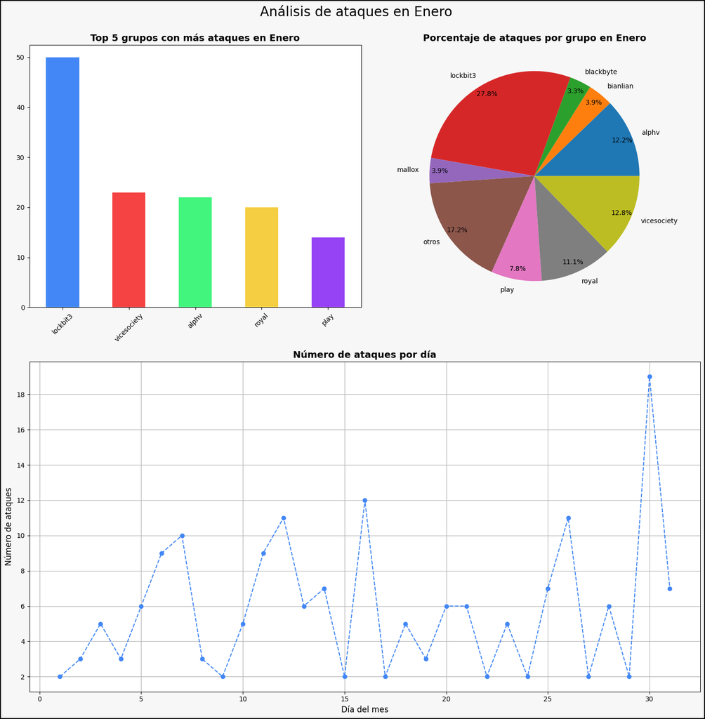

```python
MES = 1

dashboard( clean_data, MES , 6 )
# grafica_circular( mdata['group_name'].value_counts(), otros = 5, title = "Volumen de ataque por grupos en Enero" )
# grafica_barras( mdata['group_name'].value_counts().nlargest(10), title="Los 10 grupos con mas ataque en Enero" )
# grafica_evolucion(  mdata, title = "Acumulacion de volumen de ataques en el mes de Enero" )
```

## Febrero

```python
MES = 2

mdata, _ = get_month( clean_data, MES )
print( f"Datos del mes de {_} de 2023")
print( "---------------------------------------")
print( f"Numero de ataques registrados: { stats[MES]['ataques'] }")
print( f"Grupo con mas ataques registrados: {stats[MES]['grupo_maximo'] } " )
print( f"El dia mas critico ha sido el {stats[MES]['dia_critico']} de {stats[MES]['nombre_mes']} con un total de {stats[MES]['valor_maximo']} ataques")
print( "---------------------------------------")

mdata.to_excel(f'data/{MES}_{_}.xlsx')
mdata.head()
```

```
Datos del mes de Febrero de 2023
---------------------------------------
Numero de ataques registrados: 273
Grupo con mas ataques registrados: lockbit3
El dia mas critico ha sido el 12 de Febrero con un total de 19 ataques
---------------------------------------
```

|  | post_title | group_name | discovered | published | post_url | description | website |
| --- | --- | --- | --- | --- | --- | --- | --- |
| 4950 | TK Elevator | royal | 2023-02-01 07:22:10.759684 | 2023-02-01 07:22:10.759684 |  | We are moved by what moves people. By what mov... | https://www.tkelevator.com |
| 4951 | Guildford County School | vicesociety | 2023-02-01 07:23:02.030421 | 2023-02-01 07:23:02.030421 |  | As a School founded in 1905 we have deep-roote... | http://www.guildfordcounty.co.uk/ |
| 4952 | N** ****** | bianlian | 2023-02-01 19:17:05.767291 | 2023-02-01 19:17:05.767291 |  | An international textile trading company. The ... |  |
| 4953 | pharmagestao.com.br | lockbit3 | 2023-02-02 02:38:08.823145 | 2023-02-02 02:38:08.823145 |  | Due to the growth of the Preo Baixo pharmacy n... |  |
| 4954 | SOTO Consulting Engineers | alphv | 2023-02-02 07:18:25.295445 | 2023-02-02 07:18:25.295445 |  | ALL DATA AVAILABLE FOR DOWNLOADING!!! | https://soto.com.au/ |

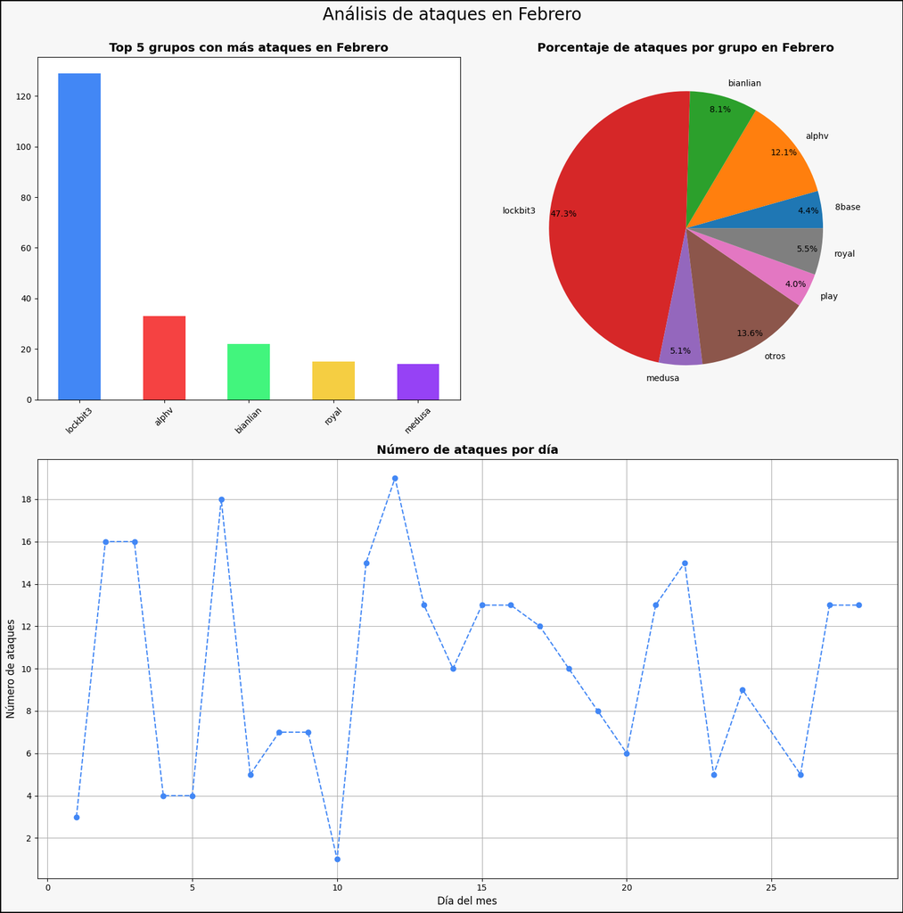

```python
MES = 2
dashboard( clean_data, MES , 10 )
```

## Marzo

```python
MES = 3

mdata, _ = get_month( clean_data, MES )
print( f"Datos del mes de {_} de 2023")
print( "---------------------------------------")
print( f"Numero de ataques registrados: { stats[MES]['ataques'] }")
print( f"Grupo con mas ataques registrados: {stats[MES]['grupo_maximo'] } " )
print( f"El dia mas critico ha sido el {stats[MES]['dia_critico']} de {stats[MES]['nombre_mes']} con un total de {stats[MES]['valor_maximo']} ataques")
print( "---------------------------------------")

mdata.to_excel(f'data/{MES}_{_}.xlsx')
mdata.head()
```

```
Datos del mes de Marzo de 2023
---------------------------------------
Numero de ataques registrados: 487
Grupo con mas ataques registrados: clop
El dia mas critico ha sido el 23 de Marzo con un total de 50 ataques
---------------------------------------
```

|  | post_title | group_name | discovered | published | post_url | description | website |
| --- | --- | --- | --- | --- | --- | --- | --- |
| 5208 | laxmi.com | lockbit3 | 2023-03-01 07:12:42.290406 | 2023-03-01 07:12:42.290383 |  |  |  |
| 5209 | hico-ics.com | lockbit3 | 2023-03-01 07:13:06.898716 | 2023-03-01 07:13:06.898695 |  | HiCo-ICS has been a leading global provider of... |  |
| 5210 | egas.no | lockbit3 | 2023-03-01 09:12:49.560173 | 2023-03-01 09:12:49.560146 |  |  |  |
| 5211 | Kenya Airports Authority | medusa | 2023-03-01 09:14:02.246920 | 2023-03-01 08:37:05.123450 | http://medusaxko7jxtrojdkxo66j7ck4q5tgktf7uqsq... | Kenya Airports Authority (KAA) is the owner an... |  |
| 5213 | tjel.net | lockbit3 | 2023-03-01 11:13:41.946144 | 2023-03-01 11:13:41.946121 |  | AboutUs: Thai Jurong Engineering Limited (TJEL... |  |

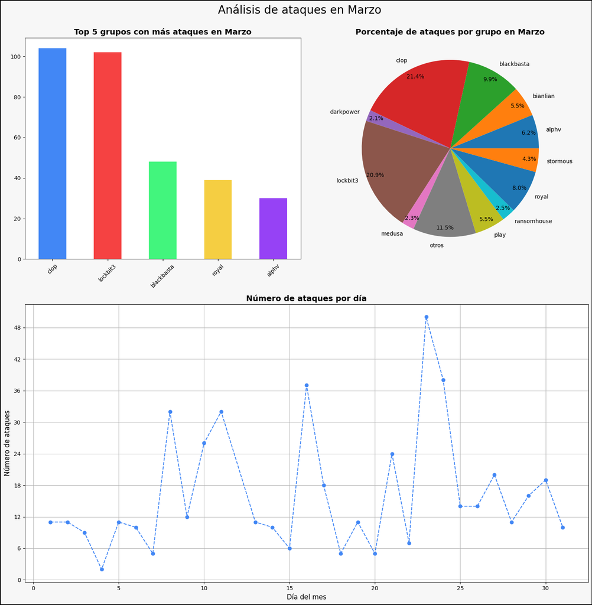

```python
MES = 3
dashboard( clean_data, MES , 10 )
```

## Abril

```python
MES = 4

mdata, _ = get_month( clean_data, MES )
print( f"Datos del mes de {_} de 2023")
print( "---------------------------------------")
print( f"Numero de ataques registrados: { stats[MES]['ataques'] }")
print( f"Grupo con mas ataques registrados: {stats[MES]['grupo_maximo'] } " )
print( f"El dia mas critico ha sido el {stats[MES]['dia_critico']} de {stats[MES]['nombre_mes']} con un total de {stats[MES]['valor_maximo']} ataques")
print( "---------------------------------------")

mdata.to_excel(f'data/{MES}_{_}.xlsx')
mdata.head()
```

```
Datos del mes de Abril de 2023
---------------------------------------
Numero de ataques registrados: 538
Grupo con mas ataques registrados: malas
El dia mas critico ha sido el 9 de Abril con un total de 182 ataques
---------------------------------------
```

|  | post_title | group_name | discovered | published | post_url | description | website |
| --- | --- | --- | --- | --- | --- | --- | --- |
| 5678 | TRUSSWAY | alphv | 2023-04-01 10:42:25.447293 | 2023-04-01 09:22:34.040000 | http://alphvmmm27o3abo3r2mlmjrpdmzle3rykajqc5x... | Trussway is the leading U.S. manufacturer of f... | https://trussway.com/ |
| 5679 | p-and-r.com | lockbit3 | 2023-04-01 21:02:49.808424 | 2023-04-01 19:48:00.000000 | http://lockbitaptbdiajqtplcrigzgdjprwugkkut63n... | P&R Enterprises, Inc. was founded in 1968 and ... |  |
| 5681 | Ruekert & Mielke | alphv | 2023-04-02 02:27:02.091580 | 2023-04-01 21:43:09.209000 | http://alphvmmm27o3abo3r2mlmjrpdmzle3rykajqc5x... | Ruekert &amp; Mielke, Inc. (R/M) is a 100% emp... | https://ruekertmielke.com |
| 5682 | Arandell Corp | medusa | 2023-04-02 07:10:31.842394 | 2023-04-02 06:20:48.123450 | http://medusaxko7jxtrojdkxo66j7ck4q5tgktf7uqsq... | Founded in 1922, Arandell provides premedia, c... |  |
| 5683 | Goldenbear.com & mjhallandcompany.com | moneymessage | 2023-04-02 21:22:32.957421 | 2023-04-02 21:22:32.957382 | http://blogvl7tjyjvsfthobttze52w36wwiz34hrfcmo... | GOLDENBEAR.COMGolden Bear is a leading provide... |  |

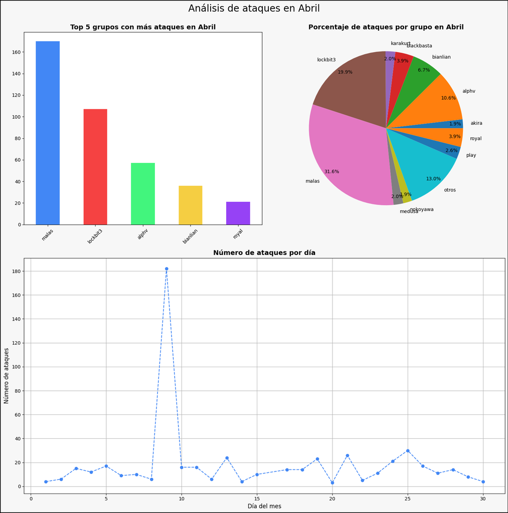

```python
MES = 4
dashboard( clean_data, MES , 10 )
```

## Mayo

```python
MES = 5

mdata, _ = get_month( clean_data, MES )
print( f"Datos del mes de {_} de 2023")
print( "---------------------------------------")
print( f"Numero de ataques registrados: { stats[MES]['ataques'] }")
print( f"Grupo con mas ataques registrados: {stats[MES]['grupo_maximo'] } " )
print( f"El dia mas critico ha sido el {stats[MES]['dia_critico']} de {stats[MES]['nombre_mes']} con un total de {stats[MES]['valor_maximo']} ataques")
print( "---------------------------------------")

mdata.to_excel(f'data/{MES}_{_}.xlsx')
mdata.head()
```

```
Datos del mes de Mayo de 2023
---------------------------------------
Numero de ataques registrados: 342
Grupo con mas ataques registrados: lockbit3
El dia mas critico ha sido el 22 de Mayo con un total de 42 ataques
---------------------------------------
```

|  | post_title | group_name | discovered | published | post_url | description | website |
| --- | --- | --- | --- | --- | --- | --- | --- |
| 6044 | BridgeValley Community & Technical | akira | 2023-05-01 12:54:03.642822 | 2023-05-01 01:02:03.456789 |  | This college is a place of opportunity for a l... |  |
| 6046 | *.A. ********* & *******, ***. | bianlian | 2023-05-01 14:47:54.558003 | 2023-05-01 14:47:54.557965 | http://bianlianlbc5an4kgnay3opdemgcryg2kpfcbgc... | The company provides high quality landscape de... |  |
| 6047 | Tony Clark Consulting | alphv | 2023-05-01 23:50:17.416811 | 2023-05-01 22:35:55.407000 | http://alphvmmm27o3abo3r2mlmjrpdmzle3rykajqc5x... | Our proactive approach to information technolo... | https://www.tclarkconsulting.com/ |
| 6050 | Brighton Hill Community School | vicesociety | 2023-05-02 05:52:36.464235 | 2023-05-02 05:52:36.464212 |  | Brighton Hill Community School is a coeducatio... | http://www.brightonhill.hants.sch.uk/ |
| 6051 | EirMed Devices, part of TRELLEBORG | alphv | 2023-05-02 06:48:08.827056 | 2023-05-02 05:27:39.536000 | http://alphvmmm27o3abo3r2mlmjrpdmzle3rykajqc5x... | EirMed is a leader in the design, engineering,... | https://eirmed-devices.com |

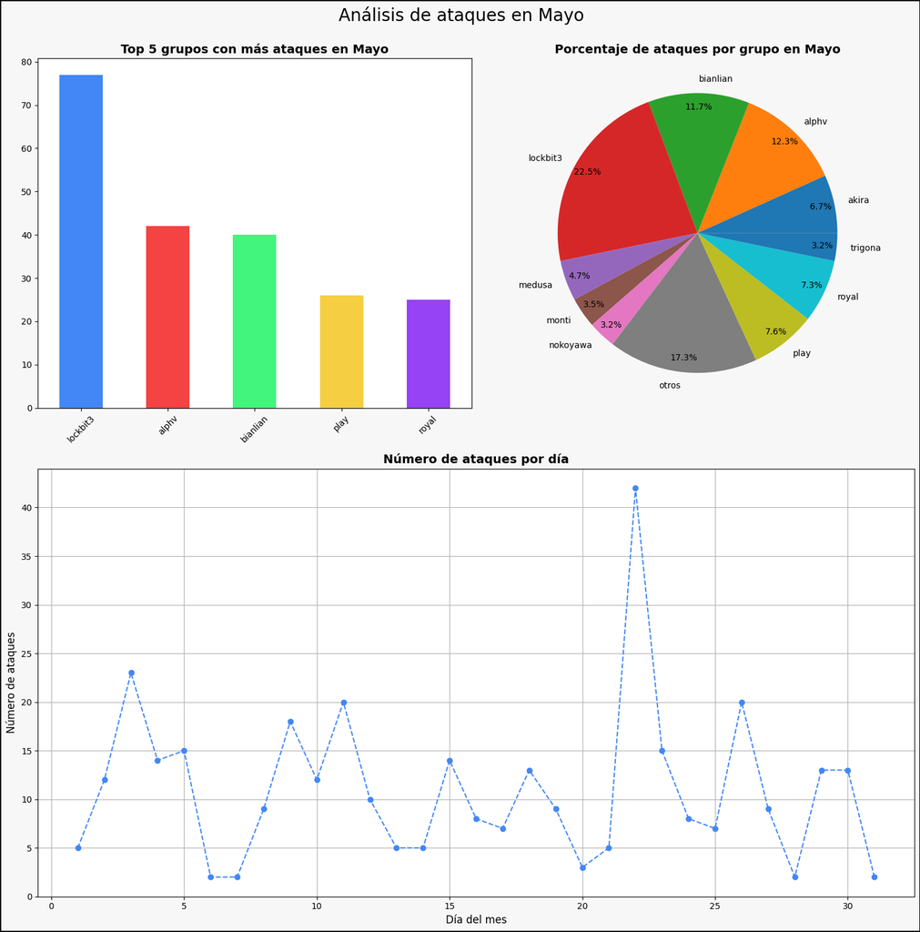

```python
MES = 5
dashboard( clean_data, MES , 10 )
```

## Junio

```python
MES = 6

mdata, _ = get_month( clean_data, MES )
print( f"Datos del mes de {_} de 2023")
print( "---------------------------------------")
print( f"Numero de ataques registrados: { stats[MES]['ataques'] }")
print( f"Grupo con mas ataques registrados: {stats[MES]['grupo_maximo'] } " )
print( f"El dia mas critico ha sido el {stats[MES]['dia_critico']} de {stats[MES]['nombre_mes']} con un total de {stats[MES]['valor_maximo']} ataques")
print( "---------------------------------------")

mdata.to_excel(f'data/{MES}_{_}.xlsx')
mdata.head()
```

```
Datos del mes de Junio de 2023
---------------------------------------
Numero de ataques registrados: 424
Grupo con mas ataques registrados: clop
El dia mas critico ha sido el 14 de Junio con un total de 33 ataques
---------------------------------------
```

|  | post_title | group_name | discovered | published | post_url | description | website |
| --- | --- | --- | --- | --- | --- | --- | --- |
| 6481 | Mission Community Hospital | ransomhouse | 2023-06-01 00:57:35.395972 | 2023-06-01 00:57:35.395948 | http://zohlm7ahjwegcedoz7lrdrti7bvpofymcayotp7... | Mission Community Hospital (MCH) is a two-camp... | https://www.mchonline.org/ |
| 6482 | Brinkmann & Niemeijer Motoren | alphv | 2023-06-01 13:50:38.933956 | 2023-06-01 12:16:43.789000 | http://alphvmmm27o3abo3r2mlmjrpdmzle3rykajqc5x... | In addition, Brinkmann &amp; Niemeijer has all... | https://www.brinkmann-niemeijer.nl |
| 6483 | Middlesex County Public Schools | akira | 2023-06-01 16:51:21.788401 | 2023-06-01 01:02:03.456789 |  | MCPS has been identified as a “School Division... |  |
| 6484 | fsd.se | lockbit3 | 2023-06-01 20:52:41.764436 | 2023-06-01 19:29:00.000000 | http://lockbitapt5x4zkjbcqmz6frdhecqqgadevyiwq... | Sweden’s first private fire consulting company... |  |
| 6485 | TY Inc | bianlian | 2023-06-01 22:53:23.734832 | 2023-06-01 22:53:23.734797 | http://bianlianlbc5an4kgnay3opdemgcryg2kpfcbgc... | Ty Inc is a manufacturer and seller of stuffed... |  |

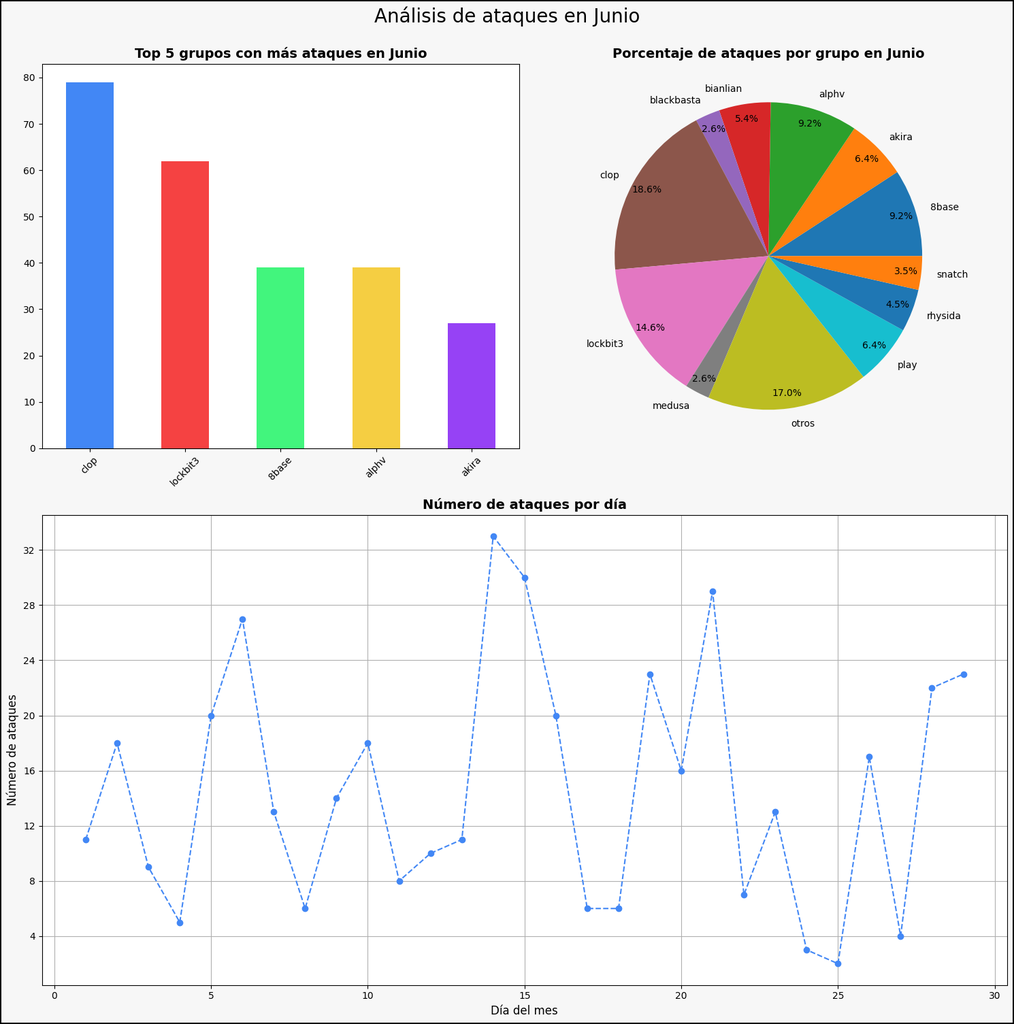

```python
MES = 6
dashboard( clean_data, MES , 10 )
```

## Comparacion de los grupos mas fuertes

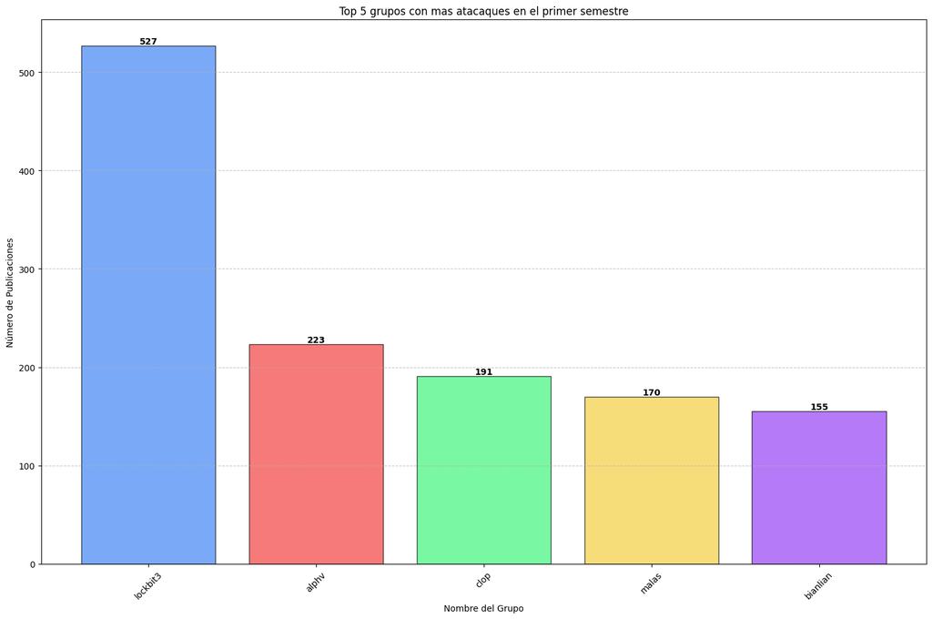

```python
grafica_barras( clean_data['group_name'].value_counts().nlargest(5), title= "Top 5 grupos con mas atacaques en el primer semestre" )
```

## Empresas con mas de un ciberataque

```python
post_title_duplicados = clean_data[clean_data['post_title'].duplicated(keep=False)]
post_title_duplicados[['post_title', 'group_name']]
```

|  | post_title | group_name |
| --- | --- | --- |
| 5192 | MSX International | snatch |
| 5439 | UnitedLex | monti |
| 5684 | Gaston College | snatch |
| 5726 | UnitedLex | alphv |
| 5751 | SIVSA | alphv |
| 6031 | Albany ENT & Allergy Services | ransomhouse |
| 6079 | SIVSA | play |
| 6183 | Albany ENT & Allergy Services | bianlian |
| 6266 | Canadian Nurses Association | snatch |
| 6383 | Global Remote Services | nokoyawa |
| 6384 | Medical University of the Americas | nokoyawa |
| 6393 | Canadian Nurses Association | nokoyawa |
| 6402 | Gaston College | nokoyawa |
| 6403 | MSX International | nokoyawa |
| 6498 | Alberta Newsprint | play |
| 6637 | Global Remote Services | snatch |
| 6793 | Medical University of the Americas | snatch |
| 6886 | Alberta Newsprint | rhysida |